# Quick Start Guide for SimpleLink™ CC32xx SDK

# 1. Introduction

This guide is intended to assist users in the initial setup and demonstration of running their first sample application. The guide explains how to install the SimpleLink<sup>TM</sup> CC32xx<sup>TM</sup> SDK and lists the various other tools required to get started with the first application

# 2. Prerequisites

The user is expected to have the following:

- SimpleLink CC32xx LaunchPad
- A computer running Microsoft® Windows® 7,Linux or macOS.
- At least one of the following IDE supported by the SimpleLink CC32xx SDK:
  - [CCS 8.0.0](http://processors.wiki.ti.com/index.php/Download_CCS)
  - [IAR for ARM 8.20.2 or higher](https://www.iar.com/iar-embedded-workbench/)
- [GNU ARM Embedded Toolchain, 7-2017-q4](https://launchpad.net/gcc-arm-embedded/7.0/7-2017-q4-major)
- FreeRTOSv10.0.0 (Optional)
  - The SimpleLink CC32xx SDK does not deliver FreeRTOS sources.  
    If the User wants to use FreeRTOS with the SDK, the user is expected to download the FreeRTOS sources from www.freertos.org
- [TI Uniflash](http://www.ti.com/tool/uniflash)

# 3 SDK - Download and Installation

## 3.1 Using the SDK Online

A quick and easy way to start working with the SDK is to use TI Resource Explorer on [dev.ti.com](http://dev.ti.com/tirex/#/).  
This online tool lets you explore the contents of the SimpleLink CC32xx SDK. You can build the examples directly using the cloud version of Code Composer Studio.  
If you choose to use the SDK online, there is no need to download anything to your local computer or install any tools.

## 3.2 Installing the SDK

You can also download the SimpleLink CC32xx SDK from TI Resource Explorer or the software product page on [TI’s website](http://www.ti.com/tool/SIMPLELINK-CC32xx-SDK).

# 4. Updating service-pack / system files in the CC32xx

It is recommended to update the service-pack to the latest service-pack available. The service-pack can be found in the following paths CC3220 Service pack - `<SDK_INSTALL_DIR>/tools/cc32xx_tools/servicepack-cc3x20`

## 4.1 Uniflash Download

Download [TI Uniflash](http://www.ti.com/tool/uniflash) and install it.

## 4.2 User guide for Uniflash ImageCreator and Programming Tool

Uniflash Image Creator user guide: [Uniflash Image Creator](http://www.ti.com/lit/SWRU469)

# 5. QuickStart for CCS IDE ( CCS or GCC Projects )

## 5.1 Download and Installation

[Download CCS](http://processors.wiki.ti.com/index.php/Download_CCS)

During the installation, the following options are recommended

- We recommend that you use the default installation folder

[figure not shown]

- Make sure that SimpleLink CC3x Wireless MCUs is selected. You can select additional processor support options as needed.

[figure not shown]

- To use a debug probe, select TI XDS Debug Probe Support and any other options you would like.

[figure not shown]

### 5.1.1 Installing the SimpleLink CC32xx SDK

- Install the SDK in the default location pointed to by the installer - `C:\ti` and Re-start CCS. CCS will automatically detect the latest install.

### 5.1.2 Add CCS Support for FreeRTOSv10

- Download FreeRTOS official version 10
- Install the software under c:
- Run CCS
- Choose Window > Preferences > Code Composer Studio > Build > Variables > Add

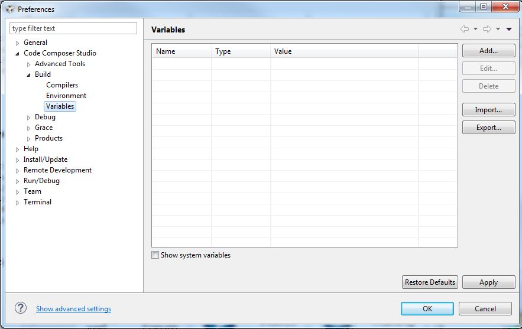

- Fill the Variable name field with *FREERTOS_INSTALL_DIR*
- Change the type to directory
- Change the Value to the `<FREERTOS_INSTALL_PATH>` and them press OK

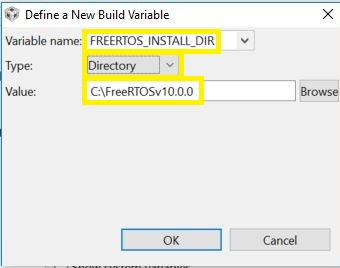

### 5.1.3 Products Settings Verification

- Choose Window > Preferences > Code Composer Studio > products

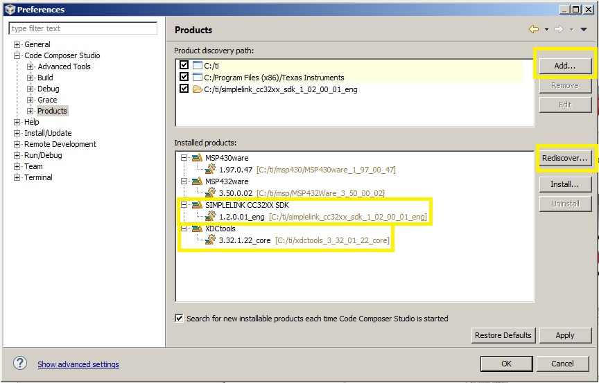

- Check that the paths in Product Discovery Path include the paths of:
  - SDK Install path
  - XDCtools
- If not, choose Add, add the paths and then choose Rediscover, after the rediscover a Install Discovered Products windows may appear.
- if the window appear it means that new products have been discovered, if the products mentioned above are in the list, choose them and choose install.

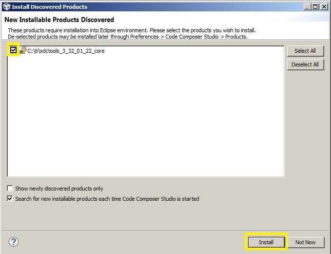

## 5.2 Execute your First Application

This section will show how to import/build/load an example

### 5.2.1 TI Resource Explorer

A quick and easy way to start working with the SDK is to use the TI Resource Explorer on [dev.ti.com/tirex](http://dev.ti.com/tirex/#/).

### 5.2.2 Import via CCS IDE

- Open CCS
- Choose Project → Import CCS Eclipse Projects from the menu.
- Select the Browse button in the Import CCS Eclipse Projects dialog and select the the directory `<SDK_INSTALL_DIR>/examples`

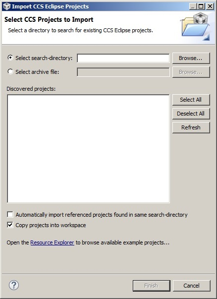

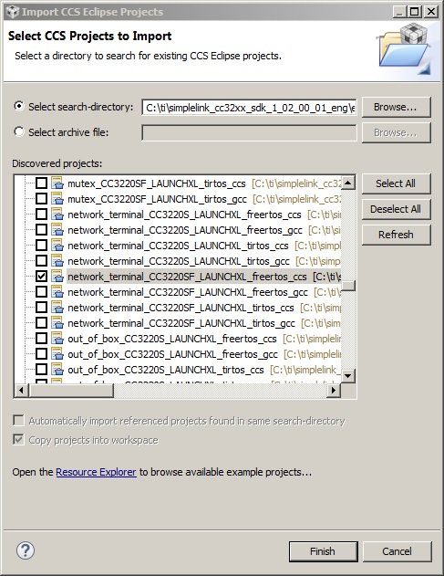

- Build and Download.  
  Plug in your launchpad, Click the build and download icon in CCS. The RTOS build for the first time takes a couple of minutes.

[figure not shown]

[figure not shown]

## 5.3 Application User guide

- Every example has a README.html that details the Example Application Design Details and how each example works

[figure not shown]

- Other example application design details and how each example works can be found in content and documentation.

## 5.4 Create a new SDK based User Application

- Do not use the New Project Creation Wizard

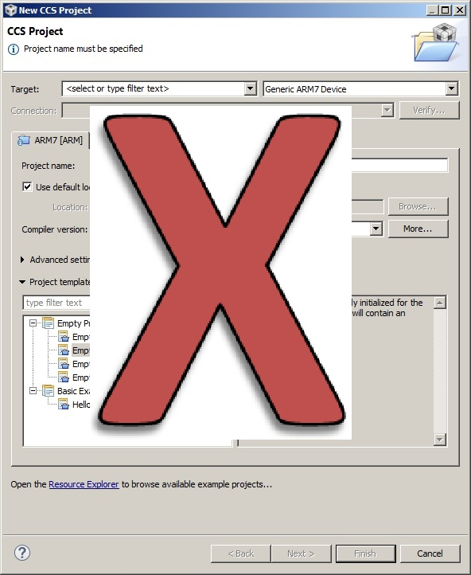

- Start with one of the example projects as shown in Execute your First Application paragraph. Each software component and each variant of the CC32xx in the SDK comes with its own set of examples.

# 6. QuickStart for IAR IDE

## 6.1 Download and Installation

- Download and install IAR Embedded Workbench for ARM. You can get IAR for ARM [here](https://www.iar.com/iar-embedded-workbench/#!?architecture=ARM):

[figure not shown]

- Make sure to select TI XDS as one of the debug probe drivers. You may also select other drivers. The driver will be installed towards the end of the installation of IAR.

[figure not shown]

### 6.1.1 Configuring the environmental variables

Before starting to work with any of the projects in the SDK, you need to load a set of environment variables that will be set to your current workspace (Custom argvars)

- The custom argvars can be found at `<SDK_INSTALL_PATH>/tools/iar/SIMPLELINK_cc32xx_SDK.custom_argvars`, if you need to modify the default path argument variables, edit the variables with the correct paths

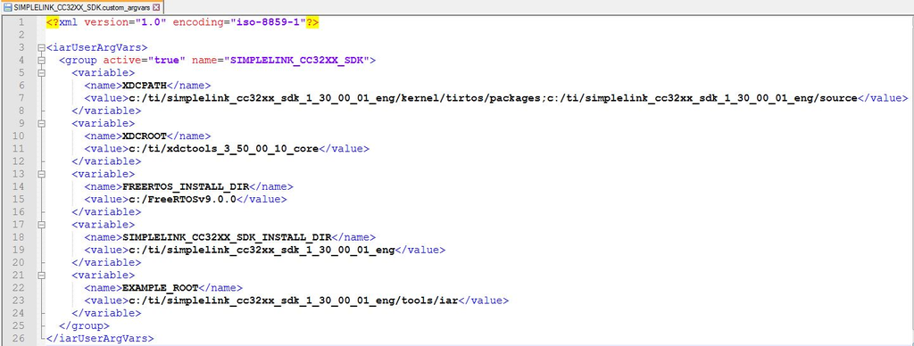

- Choose Tools -> Configure Custom Argument Variables

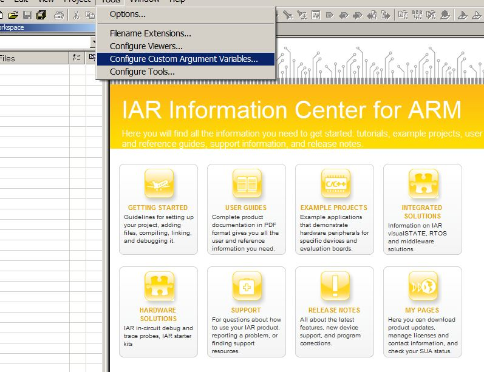

- Click Global->Import

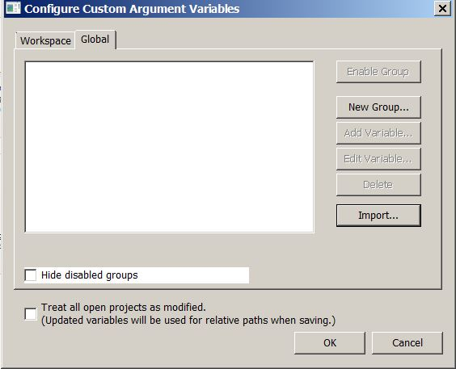

- Browse to `<SDK_INSTALL_PATH>/tools/iar`, import the custom argvars from the SDK.

[figure not shown]

- Restart IAR.

### 6.1.2 Download and install XDS Emulation Software Package

Download the latest XDS software Emulation package from [here](http://processors.wiki.ti.com/index.php/XDS_Emulation_Software_Package): Make sure IAR\CCS are closed during installation process.

## 6.2 Execute your First Application

This section will show how to import/build/load an example

### 6.2.1 Build your Kernel first, you can use a TI-RTOS, FreeRTOS or NoRTOS based example.

For this release of the SDK, the RTOS (FreeRTOS/TIRTOS) configurations are not pre-built. You will need to build the desired configurations.

#### Update your installation Paths

- Edit the imports.mak file and adjust the locations of XDCtools installation, FreeRTOS and compiler tools paths.  
  XDCTools installation is included in the CC32xx SDK.  
  The imports.mak is provided in the top-level directory of the SDK installation.

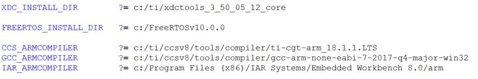

### 6.2.2 Importing your first project

This section will show how to import, build and load an example

#### 6.2.2.1 Directly accessing workspace from example folder

All Code Examples that are shipped with the SDK come with an IAR workspace. Double-Clicking the specific workspace allows you to open the project on disk and build it.

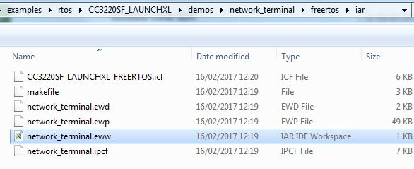